# Lab 07 - categorical variables

Ilaria Prosdocimi

29/10/2020

## The data

We focus on the dataset `Prestige`, made available in the `carData` package:

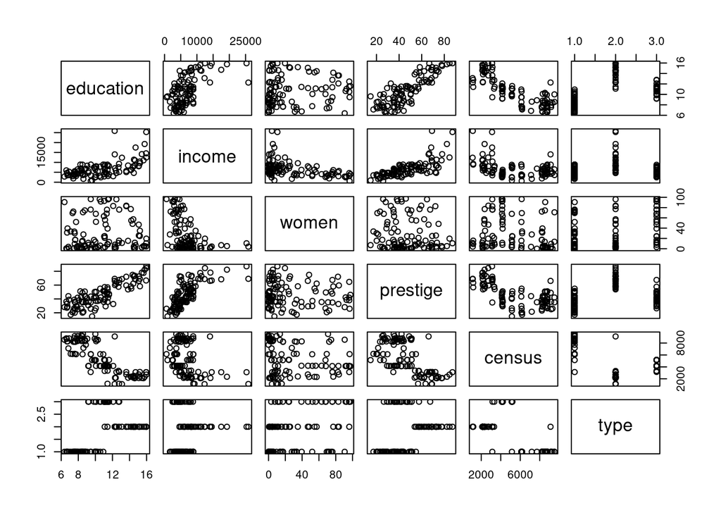

```
##                     education income women prestige census type
## gov.administrators      13.11  12351 11.16     68.8   1113 prof
## general.managers        12.26  25879  4.02     69.1   1130 prof
## accountants             12.77   9271 15.70     63.4   1171 prof
## purchasing.officers     11.42   8865  9.11     56.8   1175 prof
## chemists                14.62   8403 11.68     73.5   2111 prof
## physicists              15.64  11030  5.13     77.6   2113 prof
```

We wish to model the prestige level of different jobs as a function of income and education:

```r
fit1 <- lm(prestige ~ education+income, data = Prestige)
```

Is the model significant? Does it meet the standard assumptions?

```r
summary(fit1)
```

```
##
## Call:
## lm(formula = prestige ~ education + income, data = Prestige)
##
## Residuals:
##      Min       1Q   Median       3Q      Max
## -19.4040  -5.3308   0.0154   4.9803  17.6889
##
## Coefficients:
##               Estimate Std. Error t value Pr(>|t|)
## (Intercept) -6.8477787  3.2189771  -2.127   0.0359 *
## education    4.1374444  0.3489120  11.858  < 2e-16 ***
## income       0.0013612  0.0002242   6.071 2.36e-08 ***
## ---
## Signif. codes:  0 '***' 0.001 '**' 0.01 '*' 0.05 '.' 0.1 ' ' 1
##
## Residual standard error: 7.81 on 99 degrees of freedom
## Multiple R-squared:  0.798,  Adjusted R-squared:  0.7939
## F-statistic: 195.6 on 2 and 99 DF,  p-value: < 2.2e-16
```

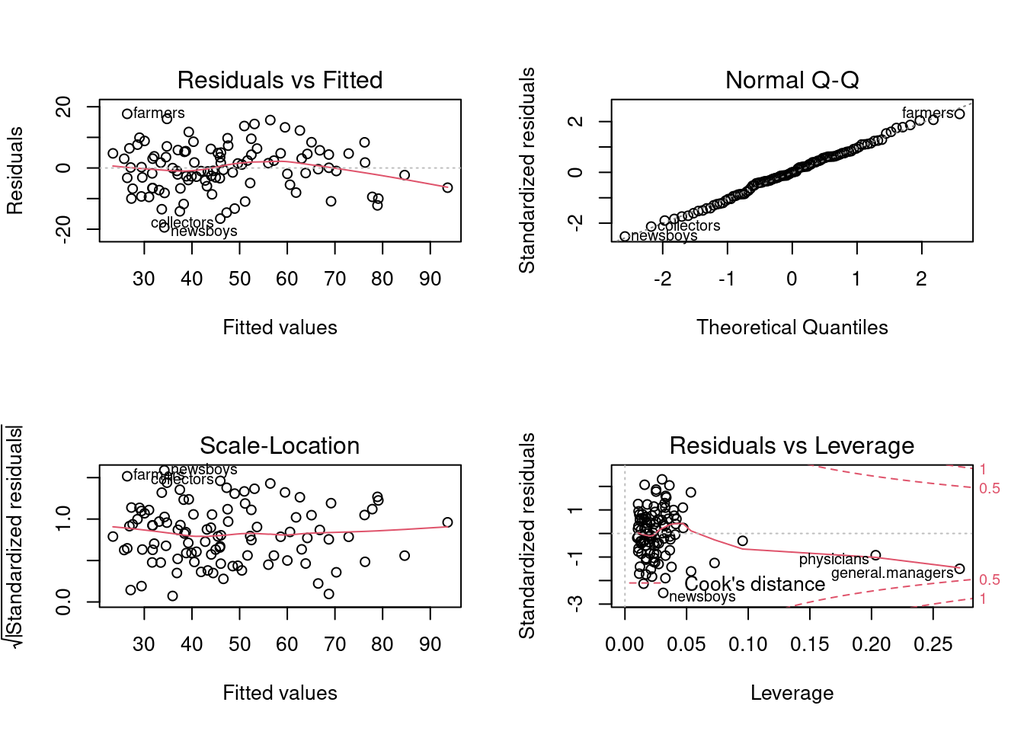

```r
par(mfrow=c(2,2))
plot(fit1)
```

Mostly seems ok. Does any of the other variables in the model appear to be worth including? Do any of them show a relationship with the residuals?

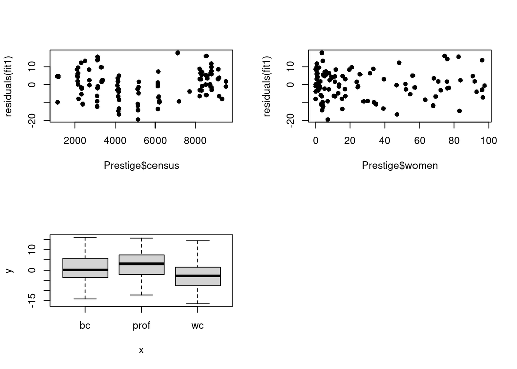

```r
par(mfrow=c(2,2),pch=16)
plot(Prestige$census, residuals(fit1))
plot(Prestige$women, residuals(fit1))
plot(Prestige$type, residuals(fit1))
```

Census appears to have some residual shape (quadratic?) and so does maybe type.

Let’s try to add them both to the original model:

```r
fit_wthcensus <- lm(prestige ~ education+income+census, data = Prestige)
summary(fit_wthcensus)
```

```
##
## Call:
## lm(formula = prestige ~ education + income + census, data = Prestige)
##
## Residuals:
##      Min       1Q   Median       3Q      Max
## -19.0412  -5.2392  -0.0678   5.1002  18.5172
##
## Coefficients:
##               Estimate Std. Error t value Pr(>|t|)
## (Intercept) -1.507e+01  8.266e+00  -1.824   0.0713 .
## education    4.653e+00  5.907e-01   7.876 4.66e-12 ***
## income       1.300e-03  2.312e-04   5.622 1.78e-07 ***
## census       5.762e-04  5.334e-04   1.080   0.2827
## ---
## Signif. codes:  0 '***' 0.001 '**' 0.01 '*' 0.05 '.' 0.1 ' ' 1
##
## Residual standard error: 7.804 on 98 degrees of freedom
## Multiple R-squared:  0.8004, Adjusted R-squared:  0.7943
## F-statistic:   131 on 3 and 98 DF,  p-value: < 2.2e-16
```

```r
fit_wthtype <- lm(prestige ~ education+income+type, data = Prestige)
summary(fit_wthtype)
```

```
##
## Call:
## lm(formula = prestige ~ education + income + type, data = Prestige)
##
## Residuals:
##      Min       1Q   Median       3Q      Max
## -14.9529  -4.4486   0.1678   5.0566  18.6320
##
## Coefficients:
##               Estimate Std. Error t value Pr(>|t|)
## (Intercept) -0.6229292  5.2275255  -0.119    0.905
## education    3.6731661  0.6405016   5.735 1.21e-07 ***
## income       0.0010132  0.0002209   4.586 1.40e-05 ***
## typeprof     6.0389707  3.8668551   1.562    0.122
## typewc      -2.7372307  2.5139324  -1.089    0.279
## ---
## Signif. codes:  0 '***' 0.001 '**' 0.01 '*' 0.05 '.' 0.1 ' ' 1
##
## Residual standard error: 7.095 on 93 degrees of freedom
##   (4 observations deleted due to missingness)
## Multiple R-squared:  0.8349, Adjusted R-squared:  0.8278
## F-statistic: 117.5 on 4 and 93 DF,  p-value: < 2.2e-16
```

None of the two variables seem to be significant. When looking at the summary of `fit_wthtype` we notice a big drop in the degrees of freedom: this is due to the fact that some observations do not have a value for `type`:

```r
Prestige[is.na(Prestige$type),]
```

```
##             education income women prestige census type
## athletes        11.44   8206  8.13     54.1   3373 <NA>
## newsboys         9.62    918  7.00     14.8   5143 <NA>
## babysitters      9.46    611 96.53     25.9   6147 <NA>
## farmers          6.84   3643  3.60     44.1   7112 <NA>
```

To compare the models we would need to re-fit them to the same dataset, otherwise AIC and significance tests can not be performed.

```r
sfit1 <- lm(prestige ~ education+income, data = Prestige[!is.na(Prestige$type),])
sfit_wthcensus <- lm(prestige ~ education+income+census, data = Prestige[!is.na(Prestige$type),])
```

The two models are not nested, so we compare them with AIC

```r
# this compares models fitted to different datasets, can not be compared
# AIC(fit_wthtype); AIC(fit_wthcensus)
AIC(sfit_wthcensus, fit_wthtype)
```

```
##                df      AIC
## sfit_wthcensus  5 676.8536
## fit_wthtype     6 669.0151
```

`fit_wthtype` seems to do better and actually we can see that when we compare the inclusion of the whole variable it is significant:

```r
anova(sfit1,fit_wthtype)
```

```
## Analysis of Variance Table
##
## Model 1: prestige ~ education + income
## Model 2: prestige ~ education + income + type
##   Res.Df    RSS Df Sum of Sq      F   Pr(>F)
## 1     95 5272.4
## 2     93 4681.3  2    591.16 5.8721 0.003966 **
## ---
## Signif. codes:  0 '***' 0.001 '**' 0.01 '*' 0.05 '.' 0.1 ' ' 1
```

We also can notice that `type` and `census` are related to each other so we really should include either one or the other in the model, not both

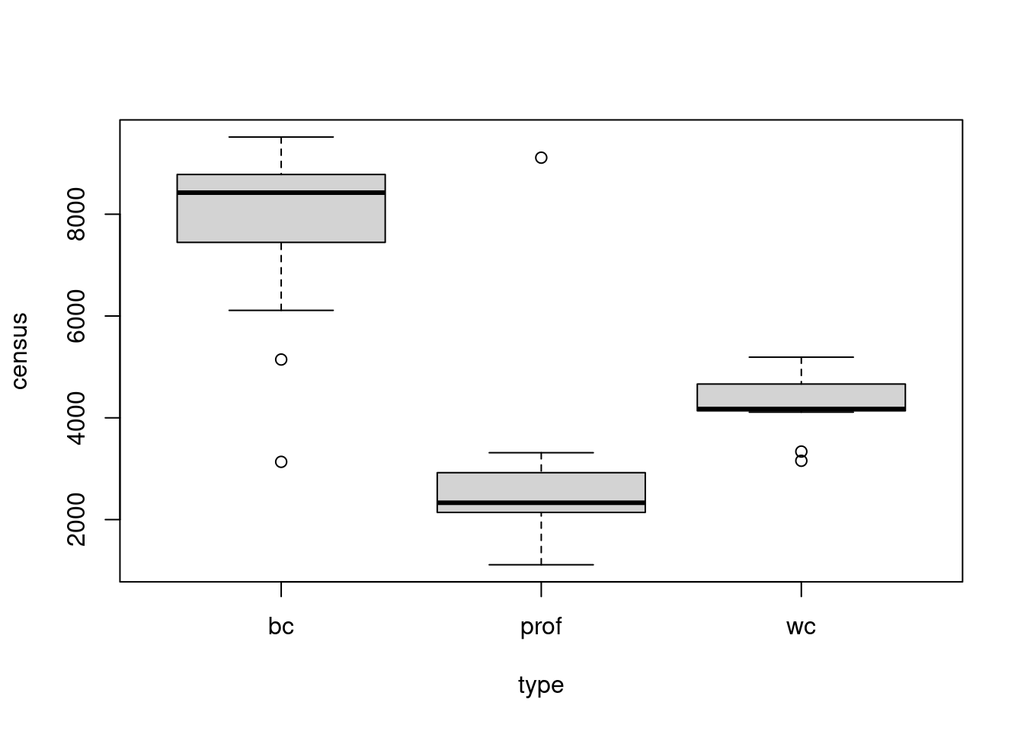

```r
plot(census~type,data=Prestige)
```

Indeed including `type` takes away the residual shape: the model does not have any over- or under- estimation for specific ranges of census.

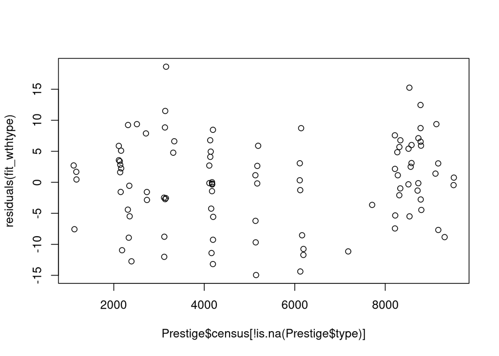

```r
plot(Prestige$census[!is.na(Prestige$type)],
     residuals(fit_wthtype))
```

Overall it makes much more sense to use a job-type classification than the census code, so we are better off using a meaningful variable as `type` rather than `census` - this is true even if the model with `census` had been found to be better in terms of AIC or any other goodness of fit measurement.

Let’s try to understand the `fit_wthtype` model better:

```r
Prestige <- Prestige[!is.na(Prestige$type),]
fit_wthtype$coefficients
```

```
##  (Intercept)    education       income     typeprof       typewc
## -0.622929165  3.673166052  0.001013193  6.038970651 -2.737230718
```

```r
cmod <- signif(fit_wthtype$coefficients,2)
```

Education and income have both positive intercept: jobs with higher levels of education and income are related to higher prestige. The `type` variable is a categorical variable with three possible values, this means we effectively estimate three different planes with different intercepts:

$$\text{if type = bc the model is}: \hat{y}_i = -0.62 + 3.7* \text{education}_i + 0.001* \text{income}_i$$
$$\text{if type = prof the model is}: \hat{y}_i = (-0.62 + 6) + 3.7* \text{education}_i + 0.001* \text{income}_i$$
$$\text{if type = wc the model is}: \hat{y}_i = (-0.62 + -2.7) + 3.7* \text{education}_i + 0.001* \text{income}_i$$

The level `bc` of the `type` variable is the baseline, the other two fitted planes differ from this plane by a constant value.

Let’s have a look at the original data underlying the model (and the fitted lines for the three groups when allowing for different intercepts):

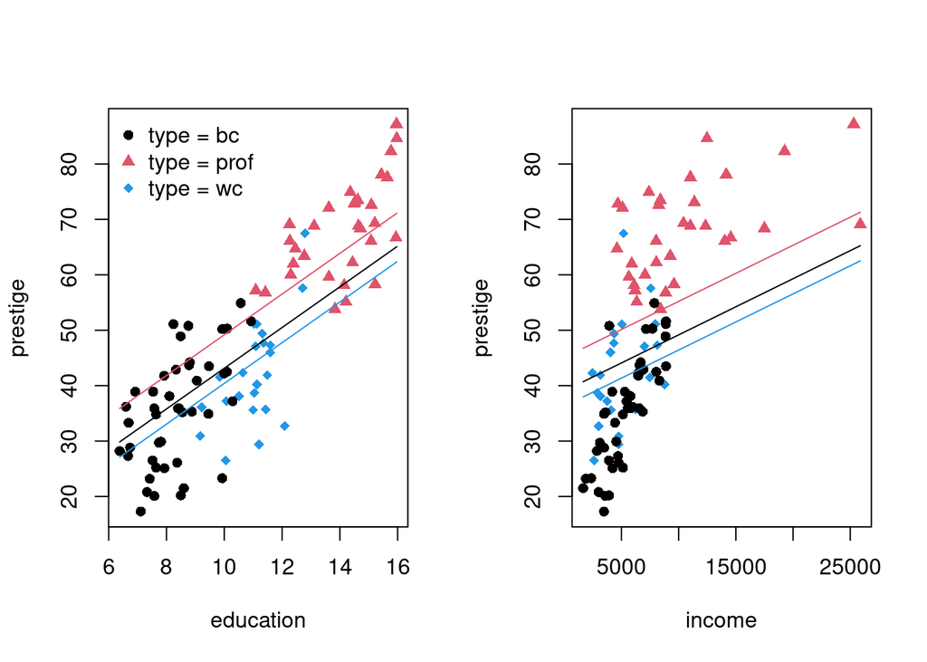

```r
par(mfrow=c(1,2))
plot(prestige~education, data=Prestige[!is.na(Prestige$type),],
     pch=16+ifelse(Prestige$type == "prof",1,0)+ifelse(Prestige$type == "wc",2,0),
     col=1+ifelse(Prestige$type == "prof",1,0)+ifelse(Prestige$type == "wc",3,0))
#### add the three lines evaluated at mean income
nd <- data.frame(education = rep(seq(min(Prestige$education),max(Prestige$education),
                                     length.out=40), times=3),
                 income = rep(mean(Prestige$income), 40*3),
                 type = rep(levels(Prestige$type), each=40))
lines(nd$education[nd$type == "bc"], predict(fit_wthtype,nd[nd$type == "bc",]))
lines(nd$education[nd$type == "prof"], predict(fit_wthtype,nd[nd$type == "prof",]),col=2)
lines(nd$education[nd$type == "wc"], predict(fit_wthtype,nd[nd$type == "wc",]),col=4)
legend("topleft", col = c(1,2,4), pch = c(16,17,18), bty = "n",
       legend = c("type = bc", "type = prof","type = wc"))
plot(prestige~income, data=Prestige[!is.na(Prestige$type),],
     pch=16+ifelse(Prestige$type == "prof",1,0)+ifelse(Prestige$type == "wc",2,0),
     col=1+ifelse(Prestige$type == "prof",1,0)+ifelse(Prestige$type == "wc",3,0))
#### add the three lines evaluated at mean income
nd <- data.frame(education = rep(mean(Prestige$education), 40*3),
                 income = rep(seq(min(Prestige$income),max(Prestige$income),
                                     length.out=40), times=3),
                 type = rep(levels(Prestige$type), each=40))
lines(nd$income[nd$type == "bc"], predict(fit_wthtype,nd[nd$type == "bc",]))
lines(nd$income[nd$type == "prof"], predict(fit_wthtype,nd[nd$type == "prof",]),col=2)
lines(nd$income[nd$type == "wc"], predict(fit_wthtype,nd[nd$type == "wc",]),col=4)
```

It is clear that the three groups have some different overall levels, and there is some interaction between `type` and both `education` and `income`. Does this need to be included in the model? Let’s fit models with interactions, i.e models in which for each group we have different intercepts and different slopes. We can have `type` interact with `income` or `education` only or with both of them. Let’s start with the latter, the most complex model:

```r
fit_intrall <- lm(prestige~education+income+type+education:type+income:type, data = Prestige)
# summary(fit_intrall)
```

The model fitted to the data is the following:

$$\begin{equation}
\begin{split}
Y_i = \beta_0 + \beta_{ed} * \text{education}_i + \beta_{inc} * \text{income}_i + \beta_{type:prod} \text{type:prof} + \beta_{type:wc} \text{type:wc} +
\beta_{ed,type:prof} * \text{education}_i * \text{type:prof} + \\
\beta_{ed,type:wc} * \text{education}_i * \text{type:wc} +
\beta_{inc,type:prof} * \text{income}_i * \text{type:prof} +
\beta_{inc,type:wc} * \text{income}_i * \text{type:wc} + \epsilon_i
\end{split}
\end{equation}$$

where $\epsilon_i$ is the error $\epsilon_i \sim N(0, \sigma^2)$.

This entails three different models with different intercepts and slopes for each group:
$$\text{if type = bc}:
Y_i = \beta_0 + \beta_{ed} * \text{education}_i + \beta_{inc} * \text{income}_i + \epsilon_i$$

$$\text{if type = prof}:
Y_i = \beta_0 + \beta_{ed} * \text{education}_i + \beta_{inc} * \text{income}_i +
\beta_{type:prof} \text{type:prof} + \\
\beta_{ed,type:prof} * \text{education}_i * \text{type:prof} +
\beta_{inc,type:prof} * \text{income}_i * \text{type:prof} +
\epsilon_i$$

$$\text{if type = wc}:
Y_i = \beta_0 + \beta_{ed} * \text{education}_i + \beta_{inc} * \text{income}_i +
\beta_{type:wc} \text{type:wc} + \\
\beta_{ed,type:wc} * \text{education}_i * \text{type:wc} +
\beta_{inc,type:wc} * \text{income}_i * \text{type:wc} + \epsilon_i$$

We can see the estimated parameter values obtained for our data:

```r
summary(fit_intrall)
```

```
##
## Call:
## lm(formula = prestige ~ education + income + type + education:type +
##     income:type, data = Prestige)
##
## Residuals:
##     Min      1Q  Median      3Q     Max
## -13.462  -4.225   1.346   3.826  19.631
##
## Coefficients:
##                      Estimate Std. Error t value Pr(>|t|)
## (Intercept)         2.276e+00  7.057e+00   0.323   0.7478
## education           1.713e+00  9.572e-01   1.790   0.0769 .
## income              3.522e-03  5.563e-04   6.332 9.62e-09 ***
## typeprof            1.535e+01  1.372e+01   1.119   0.2660
## typewc             -3.354e+01  1.765e+01  -1.900   0.0607 .
## education:typeprof  1.388e+00  1.289e+00   1.077   0.2844
## education:typewc    4.291e+00  1.757e+00   2.442   0.0166 *
## income:typeprof    -2.903e-03  5.989e-04  -4.847 5.28e-06 ***
## income:typewc      -2.072e-03  8.940e-04  -2.318   0.0228 *
## ---
## Signif. codes:  0 '***' 0.001 '**' 0.01 '*' 0.05 '.' 0.1 ' ' 1
##
## Residual standard error: 6.318 on 89 degrees of freedom
## Multiple R-squared:  0.8747, Adjusted R-squared:  0.8634
## F-statistic: 77.64 on 8 and 89 DF,  p-value: < 2.2e-16
```

```r
anova(sfit_wthcensus, fit_intrall)
```

```
## Analysis of Variance Table
##
## Model 1: prestige ~ education + income + census
## Model 2: prestige ~ education + income + type + education:type + income:type
##   Res.Df    RSS Df Sum of Sq      F    Pr(>F)
## 1     94 5175.6
## 2     89 3552.9  5    1622.8 8.1302 2.353e-06 ***
## ---
## Signif. codes:  0 '***' 0.001 '**' 0.01 '*' 0.05 '.' 0.1 ' ' 1
```

Nevertheless it might be not a very sensible model to use in practice.

What about the models in which only one of the continuous variables interact with the categorical variable?

```r
fit_intred <- lm(prestige~education+income+type+education:type, data = Prestige)
#summary(fit_intred)
fit_intrinc <- lm(prestige~education+income+type+income:type, data = Prestige)
#summary(fit_intrinc)
```

Let’s see if both interactions are needed or if we could use a reduced/nested model in which only `education` is allowed to interact with `type` or only `income` is allowed to interact with `type`:

Let’s start to assess whether the null hypothesis that we can remove the education*type interaction can be rejected

```r
anova(fit_intrall, fit_intrinc)
```

```
## Analysis of Variance Table
##
## Model 1: prestige ~ education + income + type + education:type + income:type
## Model 2: prestige ~ education + income + type + income:type
##   Res.Df    RSS Df Sum of Sq      F  Pr(>F)
## 1     89 3552.9
## 2     91 3791.3 -2    -238.4 2.9859 0.05557 .
## ---
## Signif. codes:  0 '***' 0.001 '**' 0.01 '*' 0.05 '.' 0.1 ' ' 1
```

Let’s check if the null hypothesis that we can remove the income*type interaction can be rejected

```r
anova(fit_intrall, fit_intred)
```

```
## Analysis of Variance Table
##
## Model 1: prestige ~ education + income + type + education:type + income:type
## Model 2: prestige ~ education + income + type + education:type
##   Res.Df    RSS Df Sum of Sq      F    Pr(>F)
## 1     89 3552.9
## 2     91 4504.6 -2   -951.77 11.921 2.588e-05 ***
## ---
## Signif. codes:  0 '***' 0.001 '**' 0.01 '*' 0.05 '.' 0.1 ' ' 1
```

This gets rejected quite strongly.

Lastly, is the model in which only the income*type interaction is maintained significant against the no-interaction model?

```r
anova(fit_wthtype, fit_intrinc)
```

```
## Analysis of Variance Table
##
## Model 1: prestige ~ education + income + type
## Model 2: prestige ~ education + income + type + income:type
##   Res.Df    RSS Df Sum of Sq      F    Pr(>F)
## 1     93 4681.3
## 2     91 3791.3  2    890.02 10.681 6.809e-05 ***
## ---
## Signif. codes:  0 '***' 0.001 '**' 0.01 '*' 0.05 '.' 0.1 ' ' 1
```

The interaction seems to explain a large proportion of variability.

```r
summary(fit_intrinc)
```

```
##
## Call:
## lm(formula = prestige ~ education + income + type + income:type,
##     data = Prestige)
##
## Residuals:
##      Min       1Q   Median       3Q      Max
## -12.8720  -4.8321   0.8534   4.1425  19.6710
##
## Coefficients:
##                   Estimate Std. Error t value Pr(>|t|)
## (Intercept)     -6.7272633  4.9515480  -1.359   0.1776
## education        3.0396961  0.6003699   5.063 2.14e-06 ***
## income           0.0031344  0.0005215   6.010 3.79e-08 ***
## typeprof        25.1723873  5.4669586   4.604 1.34e-05 ***
## typewc           7.1375093  5.2898177   1.349   0.1806
## income:typeprof -0.0025102  0.0005530  -4.539 1.72e-05 ***
## income:typewc   -0.0014856  0.0008720  -1.704   0.0919 .
## ---
## Signif. codes:  0 '***' 0.001 '**' 0.01 '*' 0.05 '.' 0.1 ' ' 1
##
## Residual standard error: 6.455 on 91 degrees of freedom
## Multiple R-squared:  0.8663, Adjusted R-squared:  0.8574
## F-statistic: 98.23 on 6 and 91 DF,  p-value: < 2.2e-16
```

Let’s compare the various model using AIC and BIC:

```r
AIC(fit_wthtype, fit_intred, fit_intrinc, fit_intrall)
```

```
##             df      AIC
## fit_wthtype  6 669.0151
## fit_intred   8 669.2456
## fit_intrinc  8 652.3495
## fit_intrall 10 649.9850
```

```r
BIC(fit_wthtype, fit_intred, fit_intrinc, fit_intrall)
```

```
##             df      BIC
## fit_wthtype  6 684.5249
## fit_intred   8 689.9253
## fit_intrinc  8 673.0293
## fit_intrall 10 675.8346
```

Depending on the criterion we decide to use we obtain different indication of which one is the optimal model: unluckily we do not have a way to say which one is the *right* answer.

*Additional comment: we have been using the `type` variable as provided in the dataset, but possibly the interaction between education and type is the same for the `"bc"` and `"wc"` categories. Create a new dichotomous variable and explore this alternative model*

## The baseline level: working with factors

R chooses the level `"bc"` as the baseline because it sorts the factor in alphabetical order. This means the estimated values we get are the difference in value for the intercept and slope of the `"prof"` and `"wc"` group compared to `"bc"`. What if we wished to change the baseline level and obtain the estimated parameters for the factor levels to be the values in comparison to, say `"prof"`, so that `"prof"` acts as a baseline? We need to use the `levels` option in the `factor` function to specify the levels:

```r
class(Prestige$type)
```

```
## [1] "factor"
```

```r
levels(Prestige$type)
```

```
## [1] "bc"   "prof" "wc"
```

```r
Prestige$newtype <- factor(Prestige$type, levels = c("prof","wc","bc"))
```

```r
fit_newlevels <- lm(prestige ~ education + income + newtype, data = Prestige)
fit_newlevels$coefficients
```

```
##  (Intercept)    education       income    newtypewc    newtypebc
##  5.416041486  3.673166052  0.001013193 -8.776201369 -6.038970651
```

We notice now that the estimates for the level-specific intercept are referred to the `"bc"` and `"wc"` levels, and `"prof"` now acts as a baseline. Regardless if we compare the numerical values, we can see the estimated model is effectively the same:

```r
fit_newlevels$coefficients
```

```
##  (Intercept)    education       income    newtypewc    newtypebc
##  5.416041486  3.673166052  0.001013193 -8.776201369 -6.038970651
```

```r
fit_wthtype$coefficients
```

```
##  (Intercept)    education       income     typeprof       typewc
## -0.622929165  3.673166052  0.001013193  6.038970651 -2.737230718
```

```r
nd <- data.frame(education = rep(mean(Prestige$education),3),
                 income = rep(mean(Prestige$income),3),
                 type = c("bc","prof","wc"),
                 newtype = c("bc","prof","wc"))
predict(fit_wthtype, nd)
```

```
##        1        2        3
## 46.05968 52.09865 43.32244
```

```r
predict(fit_newlevels, nd)
```

```
##        1        2        3
## 46.05968 52.09865 43.32244
```